# NBA Player Dataset

Joseph Dominic

## packages

These are the packages that will be needed in this project:

```r
library(plyr)
library(tidyverse)
library(knitr)
library(ggthemes)
library(stringr)
library(VIM)
library(car)
library(gridExtra)
```

## Dataset load into R

We upload the datasets into R.

```r
library("readxl")

season_stats <-read.csv("Seasons_Stats.csv")
salaries <- data.frame(read_excel("Player - Salaries per Year (1990 - 2017).xlsx"))
```

# Dataset description

The first dataset has 24691 observations each one with 53 variables. The second one, contains 11837 observations of 7 variables.

That amount of data is too big for the purpose of this analysis, so we will reduce the dimensions of both datasets. The idea is to join both datasets to get a full dataset with player stats and salaries. After that, we will select only the data from the 2016-17 season. We will also use the salaries of the 2017-18 season.

The remaining data will not be considered in the main analyses, though in the last section, it will be used to make some visualizations.

The selected variables are the following. From the first dataset:

- `Player`: Name of the player.
- `Pos`: Position of the player. It can be one of the following 5: PG, SG, SF, PF, C, or a combination of those.
- `Age`: Age of the player.
- `Tm`: Team of the player.
- `G`: Games played by the player on that season.
- `GS`: Games started by the player on that season, i.e., games where the player was on the starting line-up.
- `MPG`: Minutes Played per game.
- `PPG`: Points scored per game.
- `APG`: Assists made per game.
- `RPG`: Rebounds per game.
- `SPG`: Steals per game.
- `BPG`: Blocks per game.
- `TOPG`: Turnovers per game.
- `PFPG`: Personal fouls per game.
- `PER`: Player Efficiency Rating (available since the 1951-52 season); PER is a rating developed by ESPN.com columnist John Hollinger. In John’s words, “The PER sums up all a player’s positive accomplishments, subtracts the negative accomplishments, and returns a per-minute rating of a player’s performance.”
- `TS.`: TS%, True Shooting Percentage, a measure of shooting efficiency that takes into account field goals, 3-point field goals, and free throws.
- `USG.`: Usage Percentage (available since the 1977-78 season in the NBA). Usage percentage is an estimate of the percentage of team plays used by a player while he was on the floor.
- `WS`: an estimate of the number of wins contributed by a player.
- `VORP`: Value Over Replacement Player (available since the 1973-74 season in the NBA); a box score estimate of the points per 100 TEAM possessions that a player contributed above a replacement-level (-2.0) player, translated to an average team and prorated to an 82-game season
- `FG.`: Field Goal Percentage.
- `X2P.`: 2-Point Field Goal Percentage.
- `X3P.`: 3-Point Field Goal Percentage (available since the 1979-80 season in the NBA).

And from the second dataset:

- `Salary.in..`: The amount of money that the players gets for the season, in dollars.

## Importance of the dataset and questions that will be studied

There are three main questions that we would like to answer:

- Are the Win Shares the factor that is more correlated to the salary of a player?
- Is there any significant difference in any of the main statistics for the different five positions of the game?
- Can the players’ salaries be predicted?

To answer these questions, we will work with the data from the 2016-17 season, as it is the last for which there is data on both salaries and in-game stats.

Furthermore, we try to answer some small questions with the help of some plots. The questions that we pose are the following:

- How did the number of points scored evolved through the years?
- Which teams are the ones which expent the most on salaries? Were they successfull teams?
- Was there any change in the number of three points attempts in the history of the league?

# Data cleaning

We start with some basic cleaning of the datasets. First, let us remove two variables that are empty and will not be used.

```r
# remove blanl & blank2: empty variables
season_stats <- season_stats %>% select(-c(blanl, blank2))
```

We now restrict the datasets to the 2016-17 season, as it is the one which has more interest to our analysis (we want to study the statistics for the las available season, that is, 2016-17).

```r
# year 2017: season 16_17
salaries_2017 <- salaries %>% filter(Season.End==2017)
season_stats_2017 <- season_stats %>% filter(Year==2017)
# update the levels in the subset 2017
#stats
season_stats_2017$Pos <- factor(season_stats_2017$Pos)
season_stats_2017$Player <- factor(season_stats_2017$Player)
season_stats_2017$Tm <- factor(season_stats_2017$Tm)
#salaries
salaries_2017$Player.Name <- factor(salaries_2017$Player.Name)
salaries_2017$Team <- factor(salaries_2017$Team)
# update and match the levels on both teams
salaries_2017$Team <- revalue(salaries_2017$Team, c("CHA"="CHO", "NJN"="BRK", "NOH" = "NOP"))
```

## Zeroes and NAs handling

```r
View(salaries_2017 %>%
  select(everything()) %>%
  summarise_all(funs(sum(is.na(.)))))
```

The other dataset does have some null values that should be analyzed.

```r
# number of NAs
View(season_stats_2017 %>%
  select(everything()) %>%
  summarise_all(funs(sum(is.na(.)))))
```

Now we should think if those values should be imputed or else if we can drop them from the dataset. Let us examine those samples which have some missing values and then decide what is more suitable for each case.

```r
### lists--NA
# residual: players who didn't play much
View(season_stats_2017 %>%
  filter(is.na(FT.) == TRUE) %>%
  select(c("Player", "Tm", "Pos", "G", "MP")) %>%
  arrange(desc(G)) %>%
  head(n=10))
# important: some big stars included
View(season_stats_2017 %>%
  filter(is.na(X3P.) == TRUE) %>%
  select(c("Player", "Tm", "Pos", "G", "MP")) %>%
  arrange(desc(G)) %>%
  head(n=10))
```

While the first case is residual, as only players with few minutes played through the season appear, the second case is more important, as it contains some good overall players, like Capela or Whiteside, and others who logged a big number of minutes.

For the first case, we will drop the values and for the second we will impute them.

```r
#drop values with NA values in FT.
season_stats_2017<- season_stats_2017 %>% drop_na(FT.)
```

Let us see how many NAs are still present on the dataset:

```r
View(season_stats_2017 %>%
  select(everything()) %>%
  summarise_all(funs(sum(is.na(.)))))
```

We will see which are the samples with NAs in `X2p.`

```r
# check X2P.
View(season_stats_2017 %>%
  filter(is.na(X2P.) == TRUE) %>%
  select(c("Player", "Tm", "Pos", "G", "MP")) %>%
  arrange(desc(G)))
```

It is just one player who didn’t play many minutes, so we will drop this sample from the dataset.

```r
# drop the sample
season_stats_2017<- season_stats_2017 %>%
  drop_na(X2P.)
```

Next, we deal with the imputation of the NAs values of the variable `X3P.`.

```r
View(season_stats_2017 %>%
  filter(is.na(X3P.) == TRUE) %>%
  select(c("Player", "Tm", "Pos", "G", "MP", "X3P", "X3PA")) %>%
  arrange(desc(X3P)) %>%
  head(n=10))
```

We see that those values are empties because those players did not shoot any 3-pointer through the entire season. Thus, it would make sense not to consider the variable for them. To simplify the analysis, we can imput the value 0. If they didn’t shoot any 3, they probably would have a bad percentage anyway.

```r
#replace NAs by 0
season_stats_2017 <- season_stats_2017 %>%
  mutate(X3P. = replace_na(X3P., 0) )
##check the results on two of the players
View(season_stats_2017 %>%
  filter(Player %in% c("Clint Capela", "Hassan Whiteside")) %>%
  select(c(Player, X3P. )))
```

## Computing Per Game statistics

We will compute some basic per game statistics that are not included in the `season_stats` dataset, namely, points per game (PPG), assiste per game (APG), rebounds per game (RPG), blocks per game (BPG), steals per game (SPG), turnovers per game (TOPG), personal fouls per game (PFPG) and minutes per game (MPG). Those variables will be used in the following analyses and are more convenient to understand them and to compare the values of the different players.

```r
season_stats_2017 <- season_stats_2017 %>%
  mutate(PPG = PTS/G, APG = AST/G, RPG = TRB/G,
         BPG = BLK/G, SPG = STL/G, MPG = MP/G,
         TOPG = TOV/G, PFPG = PF/G )
```

## Join the two tables

Finally, we can create the table that resulsts from the union of the stats of 2017 table and the 2017 salaries.

```r
# join stats with salaries: join by player and team to avoid duplicities of players
salaries_2017_join <- salaries_2017 %>%
  select(c(Player.Name, Team, Salary.in..))
stats_with_salaries <- inner_join(season_stats_2017, salaries_2017_join,
                                  by = c('Player' = 'Player.Name', "Tm"="Team"))
View(head(stats_with_salaries))
```

Now let us analyze if there were any NAs created with this process.

```r
View(stats_with_salaries %>%
  select(everything()) %>%
  summarise_all(funs(sum(is.na(.)))))
```

We see that no null values were introduced.

## Subset selection

After cleaning the data, we will select a subset of all the variables, with which we will continue the analysis. Nevertheless, the data cleaning made in the previous section can be useful for further analyses on the dataset.

```r
subset <- stats_with_salaries %>%
  select(c(Player,Tm, Pos, Age,  G, GS, MPG, PPG, APG, RPG, BPG,
           SPG, TOPG, PFPG, WS, PER, VORP, X2P., X3P., FG., TS.,
           USG., Salary.in.. ) )
# variables that we will keep
names(subset)
```

```
##  [1] "Player"      "Tm"          "Pos"         "Age"         "G"
##  [6] "GS"          "MPG"         "PPG"         "APG"         "RPG"
## [11] "BPG"         "SPG"         "TOPG"        "PFPG"        "WS"
## [16] "PER"         "VORP"        "X2P."        "X3P."        "FG."
## [21] "TS."         "USG."        "Salary.in.."
```

## Outliers

Now we can check for outliers on every variable of the previously selected ones.

```r
boxplot.stats(subset$Age)$out
```

```
## [1] 40 39 39 39
```

```r
boxplot.stats(subset$G)$out
```

```
## integer(0)
```

```r
boxplot.stats(subset$MPG)$out
```

```
## numeric(0)
```

```r
boxplot.stats(subset$PPG)$out
```

```
##  [1] 22.90000 22.41892 23.10390 22.12821 23.89474 24.35294 25.30380
##  [8] 27.98667 27.29730 25.08065 23.66667 21.57377 29.08642 21.93151
## [15] 25.22222 26.40541 25.51351 26.98667 22.40000 22.96250 28.93421
## [22] 22.33333 25.13415 23.16456 23.14103 31.58025 23.57317
```

```r
boxplot.stats(subset$APG)$out
```

```
##  [1]  5.425000  5.514286  5.909091  6.333333  5.486842  6.275362  6.620253
##  [8]  5.794521  5.153846  7.013158 11.185185  7.283582  4.955882  5.805556
## [15]  5.192308  8.729730  4.948276  5.853333  5.111111  6.950000  6.592593
## [22]  5.133333  9.229508  6.451220  5.058824  6.681159  9.093333  6.316456
## [29]  5.160494  7.792683  5.907895  5.506329 10.653846 10.370370  6.850000
```

```r
boxplot.stats(subset$RPG)$out
```

```
##  [1] 11.468085 12.470588 11.813333 13.777778 12.777778 10.353659 12.702703
##  [8]  9.835616 13.753086 11.100000 10.350000 10.000000  9.179487 12.280488
## [15]  9.487500 10.386667 10.666667 14.129870
```

```r
boxplot.stats(subset$BPG)$out
```

```
##  [1] 1.236111 1.887500 1.123457 1.230769 1.117647 2.226667 1.158537
##  [8] 1.098765 1.596774 2.451613 1.337838 1.093750 2.641975 1.394737
## [15] 1.344828 1.279412 1.243243 1.500000 1.434783 1.131579 1.666667
## [22] 1.272727 1.653333 1.444444 1.136364 1.578947 1.900000 1.074074
## [29] 1.969697 6.000000 1.076923 1.256098 2.135802 2.090909
```

```r
boxplot.stats(subset$SPG)$out
```

```
##  [1] 1.837500 1.881579 1.895522 1.810127 2.026316 1.783784 2.000000
##  [8] 1.934426 1.706667 2.012821
```

```r
boxplot.stats(subset$TOPG)$out
```

```
##  [1] 3.378788 3.089744 3.647059 3.025316 3.774194 5.728395 4.094595
##  [8] 3.100000 3.265823 4.141026 5.407407
```

```r
boxplot.stats(subset$PFPG)$out
```

```
## [1] 4.411765
```

```r
boxplot.stats(subset$WS)$out
```

```
##  [1] 12.4 13.8 10.0 12.6 11.0  9.0 12.0 14.3 15.0 10.4  8.9 12.9  9.7 11.8
## [15] 13.6 10.3 10.1 10.6  9.4 12.6 12.7 13.1  9.5
```

```r
boxplot.stats(subset$PER)$out
```

```
##  [1] -1.4 26.1 27.5 27.6 -2.1 27.3 -2.2 -2.2 26.1 30.8 27.0 26.4 27.5 29.6
## [15] -3.4 -4.3  0.1 -1.9 26.2 31.5 -1.2  0.3 26.5 26.0 30.6
```

```r
boxplot.stats(subset$VORP)$out
```

```
##  [1]  6.9  2.6  2.8  2.9  6.3  4.5  6.2  3.9  2.5  2.9  5.2  4.0  3.2  5.4
## [15]  4.6  3.4  9.0  4.0  2.8  2.5  2.9  7.3  2.5  5.3  3.9  6.2  4.3  4.9
## [29]  2.7  5.2  3.9  2.6  4.8  5.4  2.8  3.9  4.3 12.4
```

```r
boxplot.stats(subset$X2P.)$out
```

```
##  [1] 0.167 0.273 0.200 0.231 0.000 1.000 0.717 0.222 0.200 0.000 0.694
## [12] 0.714 0.222 0.143 0.250 1.000 1.000 0.231 1.000 0.750 0.200 0.294
## [23] 0.200 0.306 0.250
```

```r
boxplot.stats(subset$X3P.)$out
```

```
##  [1] 0.000 0.000 0.000 0.000 0.000 0.000 0.000 0.000 0.000 0.000 0.000
## [12] 0.000 0.000 0.000 0.000 0.000 0.000 0.000 0.000 0.000 0.000 1.000
## [23] 0.000 0.000 0.600 0.000 0.000 0.000 0.000 0.000 0.000 0.000 1.000
## [34] 0.000 0.000 0.000 0.000 0.000 0.000 0.000 0.000 0.000 0.000 0.000
## [45] 0.000 0.000 0.000 0.000 0.000 0.000 0.000 0.000 0.000 0.000 0.000
## [56] 0.000 0.000 0.000 0.000 0.000 0.000 0.000 0.000 0.000 0.000 0.625
## [67] 0.000 0.000 0.000 0.000 0.000 0.000 0.000 0.000 0.000 0.000 0.000
## [78] 0.000 0.000 0.000 0.000 0.000 0.000
```

```r
boxplot.stats(subset$FG.)$out
```

```
##  [1] 0.625 0.643 0.671 0.622 0.100 0.214 0.662 0.652 0.200 0.000 0.617
## [12] 0.633 0.667 0.750 0.714 0.652 0.642 0.143 0.000 0.250 0.660 0.714
## [23] 0.200 0.167 0.250 0.625 1.000 0.231 1.000 0.750 0.143 0.268 0.250
## [34] 0.258
```

```r
boxplot.stats(subset$TS.)$out
```

```
##  [1] 0.355 0.703 0.387 0.381 0.184 0.306 0.798 0.239 0.102 0.773 0.753
## [12] 0.357 0.190 0.228 0.285 0.799 0.276 0.272 0.820 0.798 0.339 0.190
## [23] 0.378 0.376 0.392 0.329 0.346
```

```r
boxplot.stats(subset$USG.)$out
```

```
## [1] 33.1 32.6 34.3 36.0 34.2 35.4 39.9 34.0 41.7
```

```r
boxplot.stats(subset$Salary.in..)$out
```

```
##  [1] 20575005 24559380 22116750 20869566 22116750 26540100 22116750
##  [8] 26540100 22116750 26540100 21165675 20140838 26540100 26540100
## [15] 23180275 30963450 21165675 24328425 21165675 21165675 20072033
## [22] 25000000 22116750 22868827 21323250 23200000 26540100 22116750
```

We see that all of them correspond to values that actually correspond to real players. That means that they are values that the players can achieve, so we won’t remove those outliers.

# Data analysis

In this section, we will state three questions that we want to answer with the dataset that we constructed in the previous section. Then, analyses will be made in order to answer the questions.

First, we start by some preliminary exploratory analysis.

## Exploratory analysis

Let us explore the players with the highest values of some of the statistics: MPG, PPG, APG, RPG, TOPG, PFPG and Salary. We will output the 10 players with the higher values for the statistics.

### MPG

```r
# MPG
View(subset %>%
  select(c(Player, Pos, MPG )) %>%
  arrange(desc(MPG)) %>%
  head (n=10))
```

### PPG

```r
# PPG
View(subset %>%
  select(c(Player, Pos, PPG )) %>%
  arrange(desc(PPG)) %>%
  head (n=10))
```

### APG

```r
# APG
View(subset %>%
  select(c(Player, Pos, APG )) %>%
  arrange(desc(APG)) %>%
  head (n=10))
```

### RPG

```r
# RPG
View(subset %>%
  select(c(Player, Pos, RPG )) %>%
  arrange(desc(RPG)) %>%
  head (n=10))
```

### TOPG

```r
# TOPG
View(subset %>%
  select(c(Player, Pos, TOPG )) %>%
  arrange(desc(TOPG)) %>%
  head (n=10))
```

### PFPG

```r
# PFPG
View(subset %>%
  select(c(Player, Pos, PFPG)) %>%
  arrange(desc(PFPG)) %>%
  head (n=10))
```

### Salary

```r
# Salary
View(subset %>%
  select(c(Player, Pos, Salary.in.. )) %>%
  arrange(desc(Salary.in..)) %>%
  head (n=10))
```

## Are the Win Shares the factor that is more correlated to the salary of a player?

We start with the hypothesis that whe Win Shares (WS) is the factor that contributes the most to a player’s salary. Let’s see if that hypothesis is true.

If not, we will examine some other factors to determine which is the one more related to the salary of a player.

First, let’s check who are the 30 players with the higher WS and see how much they are getting paid

```r
# 30 players with higher WS
View(subset %>%
  select(c(Player, Tm, Pos,  WS,  Salary.in.. )) %>%
  arrange(desc(WS)) %>%
  head(n=30))
```

As a curiosity, let’s calculate the Win shares for the teams:

```r
#teams with more WS
View(stats_with_salaries %>%
  group_by(Tm) %>%
  summarise( sum_WS = sum(WS), sum_salary = sum(Salary.in..)) %>%
  select(c(Tm, sum_WS, sum_salary ))  %>%
  arrange(desc(sum_WS)))
```

```r
#normality test shapiro-wilk WS and salaries
#shapiro.test(stats_with_salaries$WS)
#shapiro.test(stats_with_salaries$Salary.in..)
#homocedasticity
#fligner.test(WS ~ Salary.in.., data = subset)
```

### Computing the correlation

```r
# correlation: WS and Salary
cor(stats_with_salaries$WS, stats_with_salaries$Salary.in.., method = 'spearman')
```

```
## [1] 0.5858834
```

The result is a correlation of $0.58$. There is some positive correlation, but is not a great one. Let’s check some other variables, to see if there is another one which is more positively correlated to the salary:

```r
subset1 <- stats_with_salaries %>%
  select(c(Player, Tm, Pos, Age, TS., WS, PER, G,
           PPG, APG, RPG, BPG, SPG, TOPG, MPG, Salary.in.. ))
cor(subset1$Salary.in.., subset1[4:15], method="spearman")
```

```
##            Age       TS.        WS       PER         G       PPG       APG
## [1,] 0.3863301 0.1910448 0.5858834 0.3985885 0.4902147 0.6183281 0.4207545
##            RPG       BPG       SPG      TOPG       MPG
## [1,] 0.5430776 0.3554451 0.4625887 0.5144228 0.6280021
```

We see that the variable that is more positively correlated to the salary is MPG, closely followed by PPG.

It can be concluded that, usually, the players that earn the most are also the ones that play more minutes per game and the ones that score more points per game. This makes sense, as if you have to spend more money on a certain player, you would expect him to ve valuable for the team and thus make him play more minutes and allow him to shoot more often.

The teams value more the points and the minutes, rather than some advanced metrics like the PER, or the True Shooting %. Nevertheless, the metric of Win Shares follows closely the PPG and MPG in correlation with salary.

Let’s compute the correlation between salaries and FG.(field goal %) to check if the players who are getting paid the most are also the ones who shoot more efficiently.

```r
cor.test(subset$FG., subset$Salary.in.., method = 'spearman')
```

```
##
##  Spearman's rank correlation rho
##
## data:  subset$FG. and subset$Salary.in..
## S = 14232416, p-value = 0.0001784
## alternative hypothesis: true rho is not equal to 0
## sample estimates:
##       rho
## 0.1722231
```

The correlation is not so high, so being an efficient scorer seems not to be highly correlated with a higher salary.

## Is there any significant difference in any of the main statistics for the different five positions of the game?

Let’s check if there are any differences in some of the different stats for the five player positions. If any differences are found, We will perform different statistical tests to check if those differences are significative or not.

```r
subset2 <- stats_with_salaries %>%
  select(c(Player, Tm, Pos, Age, WS, PPG, APG, MPG, Salary.in.. ))
  #select(c(Player, Tm, Pos, Age, TS., WS, PER, G, PPG, APG, RPG, BPG, SPG, MPG, Salary.in.. ))
```

We select the five analysis groups, i.e., the five types of players in the game. Let us see a sample of these groups.

#### Groups

##### PG

```r
group.PG <- subset2 %>%  filter(Pos == 'PG')
View(head(group.PG))
```

##### SG

```r
group.SG <- subset2 %>%  filter(Pos == 'SG')
View(head(group.SG))
```

##### SF

```r
group.SF <- subset2 %>%  filter(Pos == 'SF')
View(head(group.SF))
```

##### PF

```r
group.PF <- subset2 %>%  filter(Pos == 'PF')
View(head(group.PF))
```

##### C

```r
group.C <- subset2 %>%  filter(Pos == 'C')
View(head(group.C))
```

### Analysis planification

We are going to study if there are any significant differences in the following variables, depending on the position of the player:

- Salary
- Points per Game
- Assists per Game
- Minutes per Game
- Win shares

First of all, we must check if each of those variables are normally distributed and if there is homocedasticity. If the answer is affirmative, then an ANOVA test can be performed. If the answer is negative, we should perform a non-parametric test like the Kruskal-Wallis.

### Analysis

#### Salary

```r
# normality test
#shapiro.test(subset2$Salary.in..)
```

```r
# homocedasticity test
#View(leveneTest(Salary.in..  ~ Pos, data = subset2))
```

```r
#test_salary <- kruskal.test(Salary.in..~ Pos, data= subset2)
#test_salary
```

#### PPG

```r
# normality test
#shapiro.test(subset2$PPG)
```

```r
# homocedasticity test
#View(leveneTest(PPG  ~ Pos, data = subset2))
```

```r
#test_PPG <-  kruskal.test(PPG~ Pos, data= subset2)
#test_PPG
```

#### APG

```r
# diferencias en APG
#shapiro.test(subset2$APG)
```

```r
# homocedasticity test
#View(leveneTest(APG  ~ Pos, data = subset2))
```

```r
# normal--- we can do the anova test
#test_APG <- aov(APG~ Pos, data= subset2)
#summary(test_APG)
#summary(test_APG)[[1]]$'Pr(>F)'[1]
```

#### MPG

```r
# normality test
#shapiro.test(subset2$MPG)
```

```r
# homocedasticity test
#leveneTest(MPG  ~ Pos, data = subset2)
```

```r
#test_MPG <- kruskal.test(MPG~ Pos, data= subset2)
#test_MPG
```

#### WS

```r
# normality test
#shapiro.test(subset2$WS)
```

```r
#View(leveneTest(WS  ~ Pos, data = subset2))
```

```r
# normal--- we can do the anova test
#test_WS <- aov(WS~ Pos, data= subset2)
#summary(test_WS)
```

### Summary

```r
#DT = data.frame(
#  Variable = c("Salary","PPG","APG","MPG","WS"),
#  Result = c("No significative difference observed",
#             "No significative difference observed",
#             "Significative difference",
#             "Significative difference",
#             "Significative difference"),
#  p.value = c(sprintf("%0.3f", test_salary$p.value),
#            sprintf("%0.3f", test_PPG$p.value),
#            sprintf("%0.2e", summary(test_APG)[[1]]$'Pr(>F)'[1]),
#            sprintf("%0.2e", test_MPG$p.value),
#            sprintf("%0.3f", summary(test_WS)[[1]]$'Pr(>F)'[1]))
#)
#View(DT)
```

### Further analysis with WS, APG and MPG.

#### WS

```r
# WS
#summary(lm(WS ~ Pos, data = subset2))
```

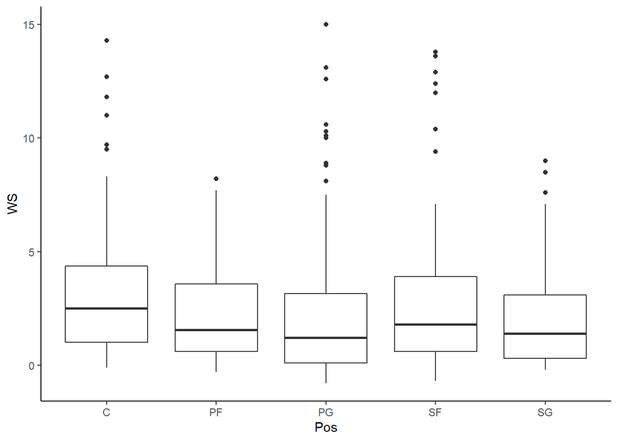

```r
subset2 %>%
  ggplot(aes(x = Pos, y = WS)) +
  geom_boxplot()+
  theme_classic()
```

It seems that the positions with the higher WS are the Centers, followed by the Small Forwards.

#### APG

```r
# APG
#summary(lm(APG ~ Pos, data = subset2))
```

We can plot those differences in a boxplot:

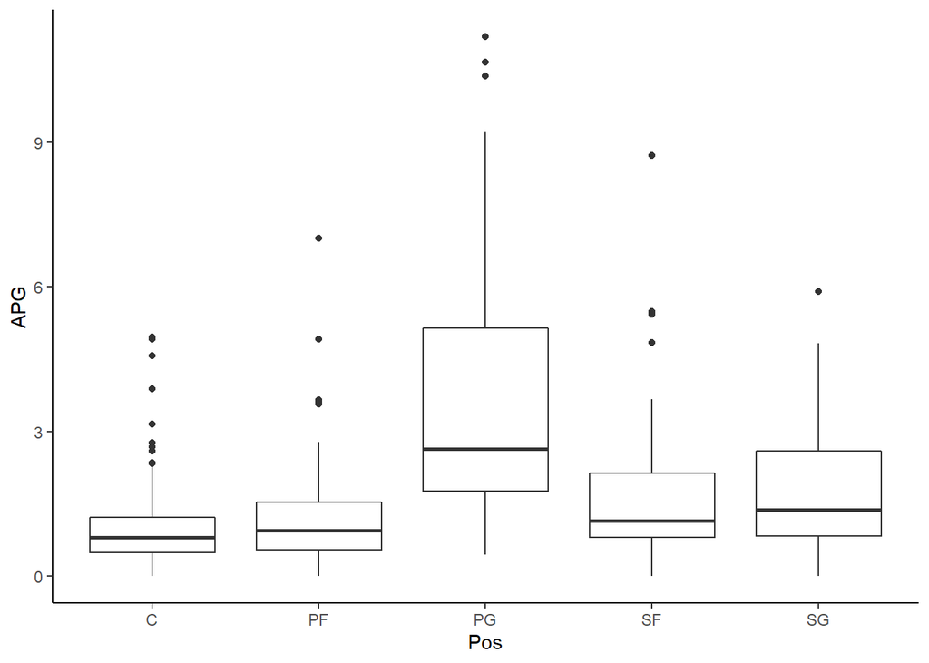

```r
subset2 %>%
  ggplot(aes(x = Pos , y = APG)) +
  geom_boxplot()+
  theme_classic()
```

```r
pairwise.t.test(subset2$APG, subset2$Pos)
```

```
##
##  Pairwise comparisons using t tests with pooled SD
##
## data:  subset2$APG and subset2$Pos
##
##    C       PF      PG      SF
## PF 1.000   -       -       -
## PG < 2e-16 < 2e-16 -       -
## SF 0.058   0.129   1.1e-15 -
## SG 0.013   0.044   1.3e-15 1.000
##
## P value adjustment method: holm
```

The results of the pairwise t-test mean that the PG has significant differences in APG with every other position in the game, while the other positions (except for SG with PF and C) do not have significant differences betweent each other.

It is quite clear that the PG are the ones with the higher APG.

#### MPG

Let us repeat the analysis for the MPG attribute.

```r
# MPG
#summary(lm(MPG ~ Pos, data = subset2))
```

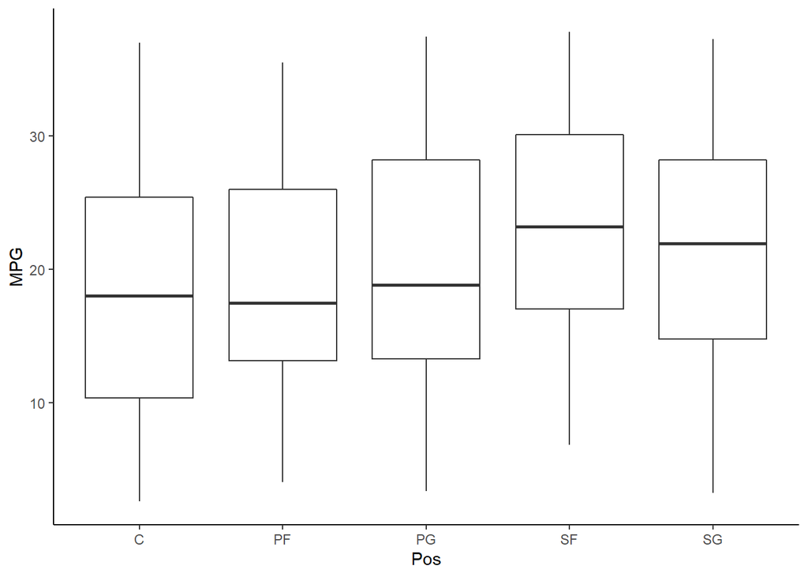

```r
subset2 %>%
  ggplot(aes(x = Pos, y = MPG)) +
  geom_boxplot()+
  theme_classic()
```

It seems that the Small Forwards are getting more minutes per game. Let us see how many players are in the league for every position in the 2016-17 season.

```r
summary(subset$Pos)
```

```
##    C   PF PF-C   PG   SF   SG
##   92   88    0   99   85  105
```

We see that the SF is the position with less players, which can be the reason that is the position with the higher MPG.

## Salary prediction model

We are going to use the following subset of variables to predict the salary:

```r
subset3 <- subset %>%
  select(-c(Tm, Player))
names(subset3)
```

```
##  [1] "Pos"         "Age"         "G"           "GS"          "MPG"
##  [6] "PPG"         "APG"         "RPG"         "BPG"         "SPG"
## [11] "TOPG"        "PFPG"        "WS"          "PER"         "VORP"
## [16] "X2P."        "X3P."        "FG."         "TS."         "USG."
## [21] "Salary.in.."
```

### Models creation

Let us create different models and compare their adjusted R-squared as an indicator of which model will make a better adjustment to the data.

Let us first use a model which uses all the variables in the subset. Let us display the summary and make some comments about it.

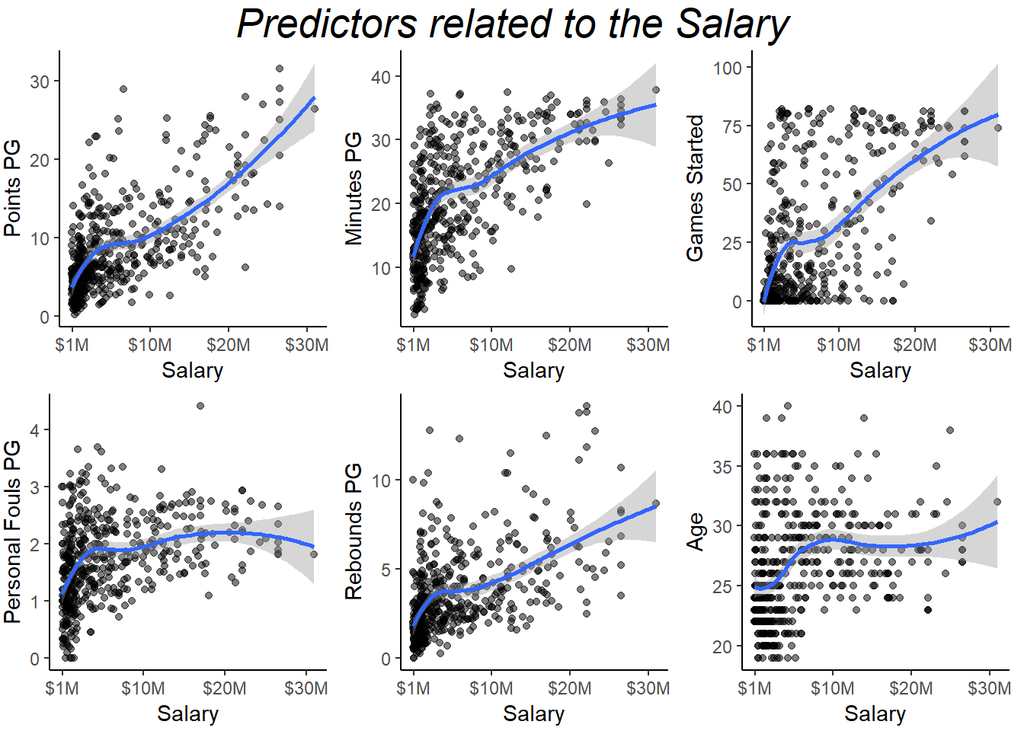

```r
# Salary vs PPG
p1 <- ggplot(subset, aes(x=Salary.in.., y=PPG)) +
  geom_point(alpha=0.5) + geom_smooth() +
  labs(x="Salary", y="Points PG") +
  theme(legend.position="none") +
  scale_x_continuous(breaks = c(100000, 10000000,
                                20000000, 30000000),
                     labels = c("$1M", "$10M",
                                "$20M", "$30M"))+
  theme_classic() +
  theme(
    plot.margin = margin(3, 7, 3, 1.5)
  )
# Salary vs MPG
p2 <- ggplot(subset, aes(x=Salary.in.., y=MPG)) +
  geom_point(alpha=0.5) + geom_smooth() +
  labs(x="Salary", y="Minutes PG") +
  theme(legend.position="none")+
  scale_x_continuous(breaks = c(100000, 10000000,
                                20000000, 30000000),
                     labels = c("$1M", "$10M",
                                "$20M", "$30M"))+
  theme_classic() +
  theme(
    plot.margin = margin(3, 7, 3, 1.5)
  )
# Salary vs GS
p3 <- ggplot(subset, aes(x=Salary.in.., y=GS)) +
  geom_point(alpha=0.5) + geom_smooth() +
  labs(x="Salary", y="Games Started") +
  theme(legend.position="none")+
  scale_x_continuous(breaks = c(100000, 10000000,
                                20000000, 30000000),
                     labels = c("$1M", "$10M",
                                "$20M", "$30M"))+
  theme_classic() +
  theme(
    plot.margin = margin(3, 7, 3, 1.5)
  )
# Salary vs PFPG
p4 <- ggplot(subset, aes(x=Salary.in.., y=PFPG)) +
  geom_point(alpha=0.5) + geom_smooth() +
  labs(x="Salary", y="Personal Fouls PG") +
  theme(legend.position="none")+
  scale_x_continuous(breaks = c(100000, 10000000,
                                20000000, 30000000),
                     labels = c("$1M", "$10M",
                                "$20M", "$30M"))+
  theme_classic() +
  theme(
    plot.margin = margin(3, 7, 3, 1.5)
  )
# Salary vs RPG
p5 <- ggplot(subset, aes(x=Salary.in.., y=RPG)) +
  geom_point(alpha=0.5) + geom_smooth() +
  labs(x="Salary", y= "Rebounds PG") +
  theme(legend.position="none")+
  scale_x_continuous(breaks = c(100000, 10000000,
                                20000000, 30000000),
                     labels = c("$1M", "$10M",
                                "$20M", "$30M"))+
  theme_classic() +
  theme(
    plot.margin = margin(3, 7, 3, 1.5)
  )
# Salary vs Age
p6 <- ggplot(subset, aes(x=Salary.in.., y=Age)) +
  geom_point(alpha=0.5) + geom_smooth() +
  labs(x="Salary", y="Age") +
  scale_x_continuous(breaks = c(100000, 10000000,
                                20000000, 30000000),
                     labels = c("$1M", "$10M",
                                "$20M", "$30M"))+
  theme_classic() +
  theme(
    plot.margin = margin(3, 7, 3, 1.5)
  )
# Represent all the subplots
grid.arrange(p1, p2, p3, p4, p5, p6,
             layout_matrix=cbind(c(1,4), c(2,5), c(3,6)),
             top = textGrob("Predictors related to the Salary",
                            gp=gpar(fontsize=20,font=3)))
```

It seems that the variables whose correlation is more clear with the salary are MPG, PPG and GS.

Let us build some more linear regression models. Then, we will select the better performing one.

```r
model1 <- lm(Salary.in.. ~ .,
             data=subset3)
summary(model1)
```

```
##
## Call:
## lm(formula = Salary.in.. ~ ., data = subset3)
##
## Residuals:
##       Min        1Q    Median        3Q       Max
## -11522379  -2537283   -287102   2510987  16497540
##
## Coefficients:
##             Estimate Std. Error t value Pr(>|t|)
## (Intercept) -3700675    3181663  -1.163 0.245402
## PosPF        -881931     765393  -1.152 0.249833
## PosPG       -3005998    1037316  -2.898 0.003943 **
## PosSF       -2011648     924789  -2.175 0.030137 *
## PosSG       -2635173     961622  -2.740 0.006384 **
## Age           403168      48388   8.332 9.95e-16 ***
## G              10859      13049   0.832 0.405734
## GS             40041      13226   3.027 0.002610 **
## MPG          -142218     114103  -1.246 0.213275
## PPG           807431     201991   3.997 7.50e-05 ***
## APG           705696     378200   1.866 0.062708 .
## RPG           719306     228368   3.150 0.001744 **
## BPG          -414566     646726  -0.641 0.521838
## SPG          1147922     943379   1.217 0.224318
## TOPG         -361199     972248  -0.372 0.710435
## PFPG        -1876593     492161  -3.813 0.000157 ***
## WS             75524     292422   0.258 0.796318
## PER          -165753     129563  -1.279 0.201448
## VORP         -582967     444824  -1.311 0.190684
## X2P.        -5850339    4627825  -1.264 0.206832
## X3P.         -144102    1826245  -0.079 0.937143
## FG.          6099856    6574182   0.928 0.353988
## TS.         -2616527    6659917  -0.393 0.694599
## USG.         -101227      90498  -1.119 0.263931
## ---
## Signif. codes:  0 '***' 0.001 '**' 0.01 '*' 0.05 '.' 0.1 ' ' 1
##
## Residual standard error: 4248000 on 445 degrees of freedom
## Multiple R-squared:  0.5937, Adjusted R-squared:  0.5727
## F-statistic: 28.27 on 23 and 445 DF,  p-value: < 2.2e-16
```

```r
model2 <- lm(Salary.in.. ~ APG + RPG + PPG + Age + BPG + MPG*PPG
             + Age*MPG,
             data=subset3)
```

```r
model3 <- lm(Salary.in.. ~ MPG +  RPG + Age + BPG + MPG*PPG + Age*MPG,
             data=subset3)
```

```r
model4 <- lm(Salary.in.. ~  Age*MPG + WS + TOPG + PFPG + GS,
             data=subset3)
```

```r
model5 <- lm(Salary.in.. ~  I(Age)^2 + I(PPG)^3+ Age*MPG +
               Pos + RPG + TS. + GS + APG*TOPG+ USG.,
             data=subset3)
```

```r
model6 <- lm(Salary.in.. ~  I(Age)^2 + I(PPG)^3+  I(PFPG)^2+
               Age*MPG + Pos + I(RPG)^2 + TS. + I(GS)^2 + APG*TOPG+
               USG.*TOPG + VORP + WS, data=subset3)
```

```r
models.table <-
  data.frame(c(1, 2, 3 ,4 ,5, 6),
                           c(summary(model1)$adj.r.squared,
                             summary(model2)$adj.r.squared,
                             summary(model3)$adj.r.squared,
                             summary(model4)$adj.r.squared,
                             summary(model5)$adj.r.squared,
                             summary(model6)$adj.r.squared),
                           c(summary(model1)$fstatistic[1],
                             summary(model2)$fstatistic[1],
                             summary(model3)$fstatistic[1],
                             summary(model4)$fstatistic[1],
                             summary(model5)$fstatistic[1],
                             summary(model6)$fstatistic[1]))
names(models.table) <- c("Model", "Adj. R-squared", "F-statistic")

View(models.table)
```

### What salary would the model predict for Free Agent players?

Now, let us now predict the salaries that some of the free agents of the 2016-2017 season would make in the season 2017-2018, according to the best performing model from the previous section. We can check the list of free agents in this [link](https://www.hoopsrumors.com/2017/06/top-50-nba-free-agents-of-2017.html).

To make this test, we will choose the following players:

- Blake Griffin.
- Steph Curry.
- Kyle Lowry.
- George Hill.
- Serge Ibaka.
- Pau Gasol.
- J.J. Redick.

```r
griffin <- subset %>% filter(Player == 'Blake Griffin')
# predicted salary
pred_griffin <- predict(model6, griffin)
curry <- subset %>% filter(Player == 'Stephen Curry')
# predicted salary
pred_curry <- predict(model6, curry)
lowry <- subset %>% filter(Player == 'Kyle Lowry')
# predicted salary
pred_lowry <- predict(model6, lowry)
hill <- subset %>% filter(Player == 'George Hill')
# predicted salary
pred_hill <- predict(model6, hill)
ibaka <- subset %>% filter(Player == 'Serge Ibaka')
# predicted salary
pred_ibaka <- predict(model6, ibaka)
p.gasol <- subset %>% filter(Player == 'Pau Gasol')
# predicted salary
pred_gasol <- predict(model6, p.gasol)
redick <- subset %>% filter(Player == 'J.J. Redick')
# predicted salary
pred_redick <- predict(model6, redick)
preds_model6 <- c(pred_griffin, pred_hill, pred_redick,
                  pred_lowry, pred_gasol, pred_ibaka, pred_curry)
```

Now we can compare those predictions with the actual salaries those players got in that season. These values are included in the `salaries` dataset. We extract that information and compare the predictions with the true values in the following lines of code.

```r
player_names <- c('Blake Griffin', 'Stephen Curry', 'Kyle Lowry',
             'George Hill', 'Serge Ibaka', 'Pau Gasol', 'J.J. Redick' )
# see the filtered players
View(subset %>% filter(Player %in% player_names))
# salaries in 2016-17
true_salaries <-
  salaries_2017 %>%
  filter(Player.Name %in% player_names) %>%
  select(Player.Name, Salary.in..)
names(true_salaries) <- c("Player", "salary_2017")
#predicted sal. for 2017-18 for these players
true_salaries$predicted_2018 <- preds_model6
# salaries they obtained in the 2017-18 season
true_salaries_2018 <-
  salaries %>%
  filter(Season.End==2018, Player.Name %in% player_names) %>%
  select(Player.Name, Salary.in..)
names(true_salaries_2018) <- c("Player", "true_salary_2018")
# see the differences
salaries_comparison <- full_join(true_salaries, true_salaries_2018,
                                 by =c('Player' = 'Player' ) )
salaries_comparison$pred_error <- salaries_comparison$true_salary_2018 -
  salaries_comparison$predicted_2018
View(salaries_comparison)
```

### Which predictions would other models make?

```r
# model 1
pred_griffin_model1 <- predict(model1, griffin)
pred_curry_model1 <- predict(model1, curry)
pred_lowry_model1 <- predict(model1, lowry)
pred_hill_model1 <- predict(model1, hill)
pred_ibaka_model1 <- predict(model1, ibaka)
pred_gasol_model1 <- predict(model1, p.gasol)
pred_redick_model1 <- predict(model1, redick)
preds_model1 <-  c(pred_griffin_model1, pred_hill_model1, pred_redick_model1,
                  pred_lowry_model1, pred_gasol_model1, pred_ibaka_model1,
                  pred_curry_model1)
# model 3
pred_griffin_model3 <- predict(model3, griffin)
pred_curry_model3 <- predict(model3, curry)
pred_lowry_model3 <- predict(model3, lowry)
pred_hill_model3 <- predict(model3, hill)
pred_ibaka_model3 <- predict(model3, ibaka)
pred_gasol_model3 <- predict(model3, p.gasol)
pred_redick_model3 <- predict(model3, redick)
preds_model3 <- c(pred_griffin_model3, pred_hill_model3, pred_redick_model3,
                  pred_lowry_model3, pred_gasol_model3, pred_ibaka_model3,
                  pred_curry_model3)
```

```r
true_salaries$predicted_model1 <-  preds_model1

true_salaries$predicted_model3 <-  preds_model3

# see the differences
salaries_comparison <- full_join(true_salaries, true_salaries_2018, by =c('Player' = 'Player' ) )
View(salaries_comparison)
```

### Conclusion

In general, the models that were built in the last sections are too simple to reflect the complexity of the NBA salary system. Some improvements are necessary in order to achieve a higher performing model, that is able to predicto more accurately the salaries.

Some ideas to improve the model would be the following:

# Data visualizations

In this section, some data visualizations are included, aiming to answer some small questions about the evolution of the league in the last years.

## How many points were scored each season through the NBA history?

```r
## evolution of points scored though the years------------------------
# group points by year
points_by_year <- season_stats %>%
  group_by(Year) %>%
  summarise(total = sum(PTS))
str(points_by_year)
```

```
## Classes 'tbl_df', 'tbl' and 'data.frame':    69 obs. of  2 variables:
##  $ Year : int  1950 1951 1952 1953 1954 1955 1956 1957 1958 1959 ...
##  $ total: int  103562 65338 58096 64356 55252 55253 59768 59654 63093 67031 ...
```

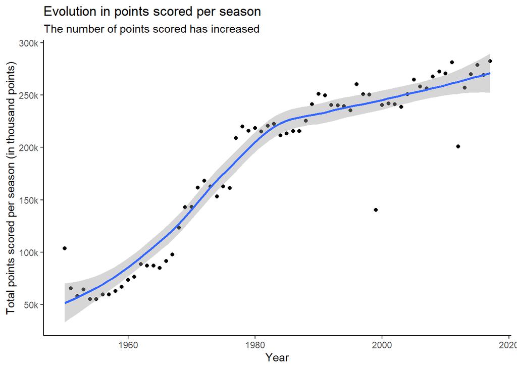

```r
# plot; geom_smooth options: method = "lm", se = FALSE
points_by_year %>%
  ggplot(aes(Year, total)) +
  geom_point()+
  geom_smooth()+
  theme_classic()+
  scale_y_continuous(breaks = c(50000, 100000,
                                150000, 200000,
                                250000, 300000),
                     labels = c("50k", "100k", "150k",
                                "200k", "250k", "300k"))+
  ggtitle('Evolution in points scored per season') +
  labs(subtitle = "The number of points scored has increased")+
  ylab("Total points scored per season (in thousand points)")
```

## Which are the teams that spent the most money on players’ salaries?

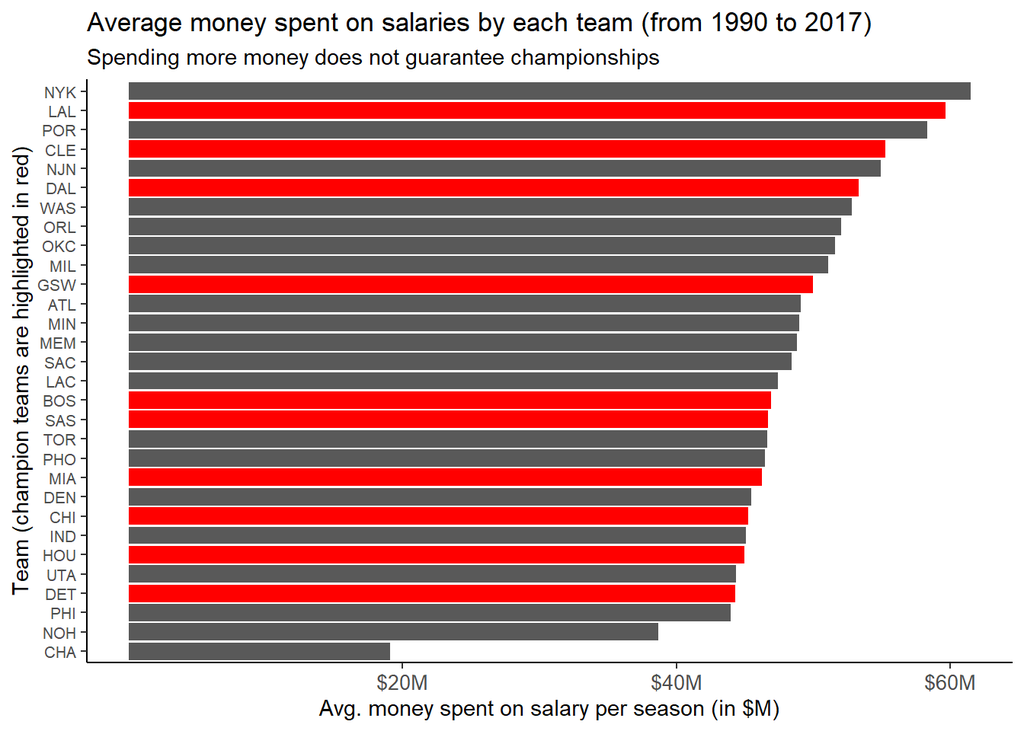

```r
### averaged salaries grouped by teams -----------
library(tidyverse)
champions_list <- c("LAL", "CLE", "DET", "GSW", "BOS",
                    "MIA", "CHI", "SAS", "HOU", "DAL")
n_seasons_salaries <- n_distinct(salaries$Season.Start)
salaries_by_team <- salaries %>% group_by(Team) %>%
  summarise(total = sum(Salary.in..), avg = sum(Salary.in..)/n_seasons_salaries) %>%
  mutate(highlight_flag = ifelse(Team %in% champions_list, T, F))
# plot: champion teams are displayed in red colour
salaries_by_team %>%
  ggplot(aes(x = reorder(Team, avg), avg)) +
  geom_bar(stat = "identity",
           aes(fill = highlight_flag)) +
  scale_fill_manual(values = c('#595959', 'red')) +
  theme_classic() +
  ggtitle('Average money spent on salaries by each team (from 1990 to 2017)') +
  labs(subtitle = "Spending more money does not guarantee championships") +
  theme(axis.text.y = element_text(size=8),
        axis.text.x = element_text(size=10),
        legend.position = 'none') +
  scale_y_continuous(breaks = c(20000000, 40000000, 60000000),
                     labels = c("$20M", "$40M", "$60M"))+
  ylab("Avg. money spent on salary per season (in $M)") +
  xlab("Team (champion teams are highlighted in red)")+
  coord_flip()
```

## Was there an evolution in the number of three point attempts through the NBA history?

```r
## evolution of 3pts attemps though the years------------------------
# group 3 pts by year :after 1982, when first collected data
threes_att_by_year <- season_stats %>% filter(Year>1982) %>%
  group_by(Year) %>%
  summarise(total = sum(X3PA))
str(threes_att_by_year)
```

```
## Classes 'tbl_df', 'tbl' and 'data.frame':    35 obs. of  2 variables:
##  $ Year : int  1983 1984 1985 1986 1987 1988 1989 1990 1991 1992 ...
##  $ total: int  4592 4599 6008 6677 9177 10735 14496 15361 16587 17433 ...
```

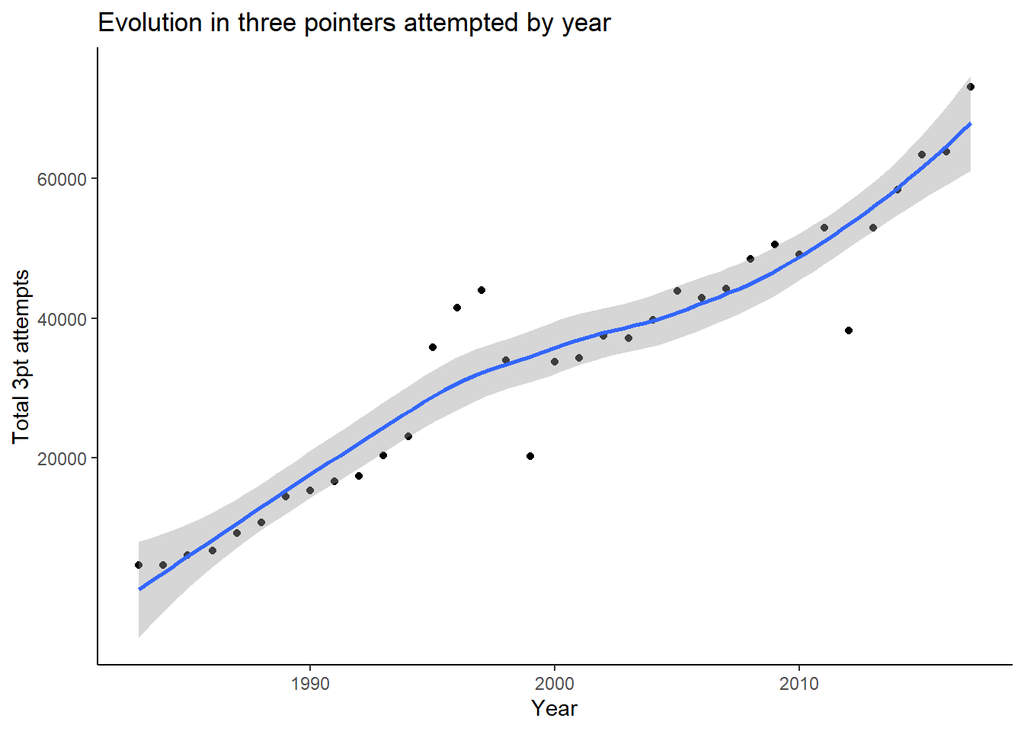

```r
# plot; geom_smooth options: method = "lm", se = FALSE
threes_att_by_year %>% ggplot(aes(Year, total)) +
  geom_point()+ geom_smooth()+
  #geom_bar(stat = "identity") +
  scale_y_continuous(breaks = c(20000, 40000,
                                60000, 80000))+
  ggtitle('Evolution in three pointers attempted by year') +
  theme_classic()+
  ylab('Total 3pt attempts')
```

# Conclusions

In this document we explored three hypothesis about the NBA stats and salaries datasets. First, we tried to determine if the Win Shares are the factor that is more correlated to the salary of a player. It was concluded that the variable that is more positively correlated to the salary is MPG, closely followed by PPG.

The reason why this happens is that, usually, the players that earn the most are also the ones that play more minutes per game and the ones that score more points per game. This makes sense, as if you have to spend more money on a certain player, you would expect him to ve valuable for the team and thus make him play more minutes and allow him to shoot more often.

Third, we created a regression model that would predict the salary of a player, given the statistics of the previous season. The conclusion is that some improvements need to be made with the model, in order to be able to obtain more precise predictions.